# Chaper 4

ville

23/11/2019

# Excercise 4

## 1) Create a new Rmarkdown

Created according to instructions as chaper 4

## 2) Loading the data and describing it

```r
install.packages("dplyr", repos="http://cran.us.r-project.org")
```

```r
install.packages("ggplot2", repos="http://cran.us.r-project.org")
install.packages("GGally", repos="http://cran.us.r-project.org")
install.packages("corrplot", repos="http://cran.us.r-project.org")
install.packages("MASS", repos="http://cran.us.r-project.org")
library(ggplot2)
library(GGally)
library(ggplot2)
library(GGally)
library(dplyr)
library(corrplot)
library(MASS)
data("Boston")
summary(Boston)
```

```
##       crim                zn             indus            chas
##  Min.   : 0.00632   Min.   :  0.00   Min.   : 0.46   Min.   :0.00000
##  1st Qu.: 0.08204   1st Qu.:  0.00   1st Qu.: 5.19   1st Qu.:0.00000
##  Median : 0.25651   Median :  0.00   Median : 9.69   Median :0.00000
##  Mean   : 3.61352   Mean   : 11.36   Mean   :11.14   Mean   :0.06917
##  3rd Qu.: 3.67708   3rd Qu.: 12.50   3rd Qu.:18.10   3rd Qu.:0.00000
##  Max.   :88.97620   Max.   :100.00   Max.   :27.74   Max.   :1.00000
##       nox               rm             age              dis
##  Min.   :0.3850   Min.   :3.561   Min.   :  2.90   Min.   : 1.130
##  1st Qu.:0.4490   1st Qu.:5.886   1st Qu.: 45.02   1st Qu.: 2.100
##  Median :0.5380   Median :6.208   Median : 77.50   Median : 3.207
##  Mean   :0.5547   Mean   :6.285   Mean   : 68.57   Mean   : 3.795
##  3rd Qu.:0.6240   3rd Qu.:6.623   3rd Qu.: 94.08   3rd Qu.: 5.188
##  Max.   :0.8710   Max.   :8.780   Max.   :100.00   Max.   :12.127
##       rad              tax           ptratio          black
##  Min.   : 1.000   Min.   :187.0   Min.   :12.60   Min.   :  0.32
##  1st Qu.: 4.000   1st Qu.:279.0   1st Qu.:17.40   1st Qu.:375.38
##  Median : 5.000   Median :330.0   Median :19.05   Median :391.44
##  Mean   : 9.549   Mean   :408.2   Mean   :18.46   Mean   :356.67
##  3rd Qu.:24.000   3rd Qu.:666.0   3rd Qu.:20.20   3rd Qu.:396.23
##  Max.   :24.000   Max.   :711.0   Max.   :22.00   Max.   :396.90
##      lstat            medv
##  Min.   : 1.73   Min.   : 5.00
##  1st Qu.: 6.95   1st Qu.:17.02
##  Median :11.36   Median :21.20
##  Mean   :12.65   Mean   :22.53
##  3rd Qu.:16.95   3rd Qu.:25.00
##  Max.   :37.97   Max.   :50.00
```

The Boston dataset has 506 rows and 14 column variables.

Columns are

**crim**= per capita crime rate by town.**zn**= proportion of residential land zoned for lots over 25,000 sq.ft. **indus** =proportion of non-retail business acres per town. **chas**= Charles River dummy variable (= 1 if tract bounds river; 0 otherwise). **nox**= nitrogen oxides concentration (parts per 10 million). **rm**= average number of rooms per dwelling. **age** =proportion of owner-occupied units built prior to 1940. **dis** =weighted mean of distances to five Boston employment centres. **rad** index of accessibility to radial highways.**tax** =full-value property-tax rate per $10,000. **ptratio** =pupil-teacher ratio by town. **black**= 1000(Bk - 0.63)^2 where Bk is the proportion of blacks by town. **lstat** =lower status of the population (percent). **medv** =median value of owner-occupied homes in $1000s.

## 3) Graphical overview of the data

```r
cor_matrix<-cor(Boston)
cor_matrix%>%round(digits=2)
```

```
##          crim    zn indus  chas   nox    rm   age   dis   rad   tax
## crim     1.00 -0.20  0.41 -0.06  0.42 -0.22  0.35 -0.38  0.63  0.58
## zn      -0.20  1.00 -0.53 -0.04 -0.52  0.31 -0.57  0.66 -0.31 -0.31
## indus    0.41 -0.53  1.00  0.06  0.76 -0.39  0.64 -0.71  0.60  0.72
## chas    -0.06 -0.04  0.06  1.00  0.09  0.09  0.09 -0.10 -0.01 -0.04
## nox      0.42 -0.52  0.76  0.09  1.00 -0.30  0.73 -0.77  0.61  0.67
## rm      -0.22  0.31 -0.39  0.09 -0.30  1.00 -0.24  0.21 -0.21 -0.29
## age      0.35 -0.57  0.64  0.09  0.73 -0.24  1.00 -0.75  0.46  0.51
## dis     -0.38  0.66 -0.71 -0.10 -0.77  0.21 -0.75  1.00 -0.49 -0.53
## rad      0.63 -0.31  0.60 -0.01  0.61 -0.21  0.46 -0.49  1.00  0.91
## tax      0.58 -0.31  0.72 -0.04  0.67 -0.29  0.51 -0.53  0.91  1.00
## ptratio  0.29 -0.39  0.38 -0.12  0.19 -0.36  0.26 -0.23  0.46  0.46
## black   -0.39  0.18 -0.36  0.05 -0.38  0.13 -0.27  0.29 -0.44 -0.44
## lstat    0.46 -0.41  0.60 -0.05  0.59 -0.61  0.60 -0.50  0.49  0.54
## medv    -0.39  0.36 -0.48  0.18 -0.43  0.70 -0.38  0.25 -0.38 -0.47
##         ptratio black lstat  medv
## crim       0.29 -0.39  0.46 -0.39
## zn        -0.39  0.18 -0.41  0.36
## indus      0.38 -0.36  0.60 -0.48
## chas      -0.12  0.05 -0.05  0.18
## nox        0.19 -0.38  0.59 -0.43
## rm        -0.36  0.13 -0.61  0.70
## age        0.26 -0.27  0.60 -0.38
## dis       -0.23  0.29 -0.50  0.25
## rad        0.46 -0.44  0.49 -0.38
## tax        0.46 -0.44  0.54 -0.47
## ptratio    1.00 -0.18  0.37 -0.51
## black     -0.18  1.00 -0.37  0.33
## lstat      0.37 -0.37  1.00 -0.74
## medv      -0.51  0.33 -0.74  1.00
```

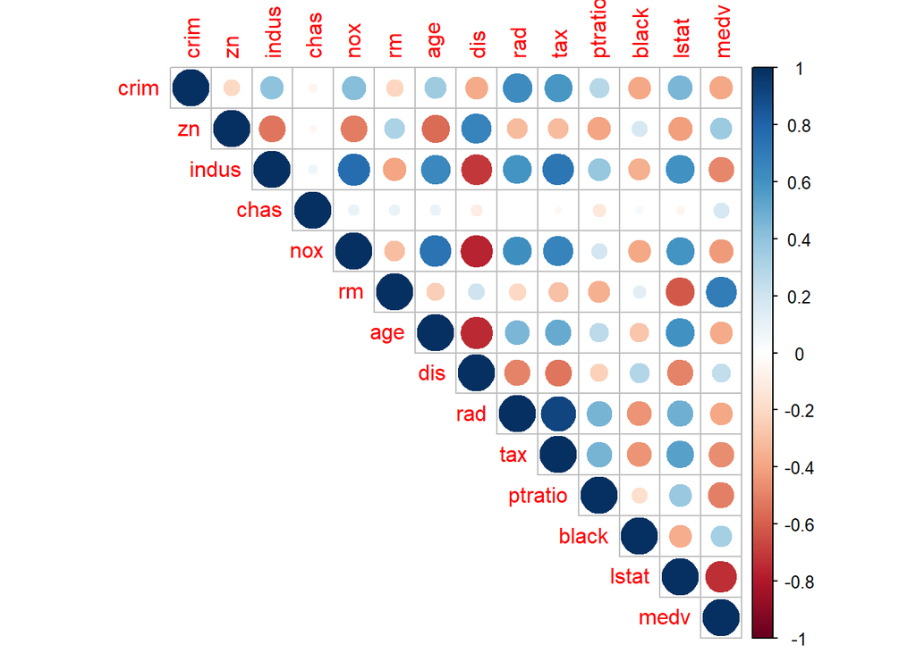

```r
corrplot(cor_matrix, method="circle", type="upper")
```

From the corrplot picture we can see which variables have correlations with each others. We can see that for example the distance of five employement centers in boston have a high correlation with proportion of non-retail bussiness acres per town. And that average number of rooms per dwelling is negatively linked to lower status of the population percent.

## 4) Standardizing the data

```r
boston_scaled <- scale(Boston)
class(boston_scaled)
```

```
## [1] "matrix"
```

```r
boston_scaled <- as.data.frame(boston_scaled)

bins <- quantile(boston_scaled$crim)
bins
```

```
##           0%          25%          50%          75%         100%
## -0.419366929 -0.410563278 -0.390280295  0.007389247  9.924109610
```

```r
crime <- cut(boston_scaled$crim, breaks = bins, labels = c("low", "med_low","med_high", "high") , include.lowest = TRUE)

table(crime)
```

```
## crime
##      low  med_low med_high     high
##      127      126      126      127
```

```r
boston_scaled <- dplyr::select(boston_scaled, -crim)
boston_scaled <- data.frame(boston_scaled, crime)
n <- nrow(boston_scaled)
ind <- sample(n,  size = n * 0.8)
train <- boston_scaled[ind,]
test <- boston_scaled[-ind,]
correct_classes <- test$crime
test <- dplyr::select(test, -crime)
```

Now the crime variable is set to 4 categories according to how high is the per capita crime rate by town.

## 5) Linear discriminant analysis

```r
lda.fit <- lda(crime ~ ., data = train)
lda.fit
```

```
## Call:
## lda(crime ~ ., data = train)
##
## Prior probabilities of groups:
##       low   med_low  med_high      high
## 0.2376238 0.2524752 0.2450495 0.2648515
##
## Group means:
##                  zn      indus         chas        nox          rm
## low       0.9549502 -0.9112759 -0.190306146 -0.8803128  0.41425623
## med_low  -0.1028172 -0.2810857 -0.002135914 -0.5812329 -0.14727441
## med_high -0.3737674  0.1750196  0.244663893  0.3913208  0.08758302
## high     -0.4872402  1.0170108 -0.014761763  1.0824844 -0.38958321
##                 age        dis        rad        tax     ptratio
## low      -0.9035262  0.9474155 -0.6887728 -0.7440724 -0.43992266
## med_low  -0.3916294  0.3968134 -0.5528850 -0.5056307 -0.06233199
## med_high  0.4011447 -0.4069307 -0.4053176 -0.3005350 -0.33218848
## high      0.8077502 -0.8588417  1.6392096  1.5148289  0.78203563
##               black        lstat        medv
## low       0.3787240 -0.783386205  0.46442449
## med_low   0.3553599 -0.151900373  0.02382864
## med_high  0.0582363 -0.007515592  0.17874772
## high     -0.7605009  0.828370043 -0.64791857
##
## Coefficients of linear discriminants:
##                 LD1         LD2          LD3
## zn       0.09122702  0.63453187 -0.947585558
## indus   -0.03176284 -0.19478420  0.468726722
## chas    -0.08879870 -0.09610159  0.069056652
## nox      0.38118209 -0.65665269 -1.259803087
## rm      -0.12361057 -0.04138027 -0.150035745
## age      0.23626759 -0.27588522 -0.236991615
## dis     -0.13965001 -0.03513775  0.258373714
## rad      3.08428833  0.95947713  0.092304097
## tax      0.10384640 -0.02668759  0.324706578
## ptratio  0.11040228  0.06541444 -0.192322119
## black   -0.13067751  0.04055453  0.144128856
## lstat    0.22531761 -0.23019566  0.499095086
## medv     0.19645438 -0.38788279  0.005903136
##
## Proportion of trace:
##    LD1    LD2    LD3
## 0.9509 0.0365 0.0126
```

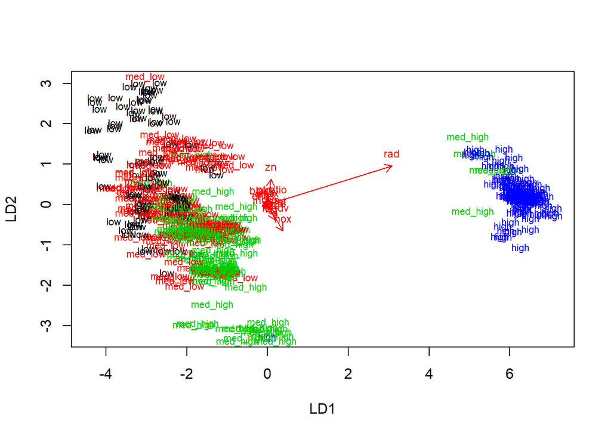

```r
lda.arrows <- function(x, myscale = 1, arrow_heads = 0.1, color = "red", tex = 0.75, choices = c(1,2)){
  heads <- coef(x)
  arrows(x0 = 0, y0 = 0,
         x1 = myscale * heads[,choices[1]],
         y1 = myscale * heads[,choices[2]], col=color, length = arrow_heads)
  text(myscale * heads[,choices], labels = row.names(heads),
       cex = tex, col=color, pos=3)
}

classes <- as.numeric(train$crime)
plot(lda.fit, dimen = 2, col = classes, pch = classes)
lda.arrows(lda.fit, myscale = 1)
```

In the above picture we can see the linear combination of the variables that separate the crime classes. The LDA model os visualized as a biplot

## 6) Predicting classes

```r
lda.pred <- predict(lda.fit, newdata = test)
table(correct = correct_classes, predicted = lda.pred$class)
```

```
##           predicted
## correct    low med_low med_high high
##   low       18      10        3    0
##   med_low    5      10        9    0
##   med_high   0       5       21    1
##   high       0       0        0   20
```